# Session 5

Victor Benito Garcia Rocha

2024-07-07

## Part I. Load the libraries and import the excel file

1.1 Rename the dataset to CCC, keep only the following variables: Annual_income, Type_income, EDUCATION, Marital_status. Print the header of CCC.

```r
library(readxl)
library(tidyverse)
library(ggplot2)
Credit_card_costumers <- read_excel(
  "Credit_card_costumersV2.xlsx"
)

Credit_card_costumers
```

| Ind_ID | GENDER | Car_Owner | Propert_Owner | CHILDREN | Annual_income | Type_Income | EDUCATION | Marital_status | Housing_type | Birthday_count | Employed_days | Mobile_phone | Work_Phone | Phone | EMAIL_ID | Type_Occupation | Family_Members | Debit card |
| --- | --- | --- | --- | --- | --- | --- | --- | --- | --- | --- | --- | --- | --- | --- | --- | --- | --- | --- |
| 5008827 | M | Y | Y | 0 | 180000 USD | Pensioner | Higher education | Married | House / apartment | -18772 | 365243 | 1 | 0 | 0 | 0 | NA | 2 | 1345-4585-4858-8687 |
| 5009744 | F | Y | N | 0 | 315000 USD | Commercial associate | Higher education | Married | House / apartment | -13557 | -586 | 1 | 1 | 1 | 0 | NA | 2 | 1858-5866-5858-6877 |
| 5009746 | F | Y | N | 0 | 315000 USD | Commercial associate | Higher education | Married | House / apartment | NA | -586 | 1 | 1 | 1 | 0 | NA | 2 | 5697-4956-2394-5866 |
| 5009749 | F | Y | N | 0 | NA | Commercial associate | Higher education | Married | House / apartment | -13557 | -586 | 1 | 1 | 1 | 0 | NA | 2 | 9877-8484-8866-1892 |
| 5009752 | F | Y | N | 0 | 315000 USD | Commercial associate | Higher education | Married | House / apartment | -13557 | -586 | 1 | 1 | 1 | 0 | NA | 2 | 3549-4563-5654-6765 |
| 5009753 | NA | Y | N | 0 | 315000 USD | Pensioner | Higher education | Married | House / apartment | -13557 | -586 | 1 | 1 | 1 | 0 | NA | 2 | 6157-7574-6521-7574 |
| 5009754 | F | Y | N | 0 | 315000 USD | Commercial associate | Higher education | Married | House / apartment | -13557 | -586 | 1 | 1 | 1 | 0 | NA | 2 | 4882-2644-4326-7326 |
| 5009894 | F | N | N | 0 | 180000 USD | Pensioner | Secondary / secondary special | Married | House / apartment | -22134 | 365243 | 1 | 0 | 0 | 0 | NA | 2 | 4812-7317-7782-4623 |
| 5010864 | M | Y | Y | 1 | 450000 USD | Commercial associate | Secondary / secondary special | Married | House / apartment | -18173 | -678 | 1 | 0 | 1 | 1 | Core staff | 3 | 7431-6156-7876-2754 |
| 5010868 | M | Y | Y | 1 | 450000 USD | Pensioner | Secondary / secondary special | Married | House / apartment | -18173 | -678 | 1 | 0 | 1 | 1 | Core staff | 3 | 8558-7216-3684-3376 |

[output cut: 1538 more lines]

```r
getwd()
```

```
## [1] "C:/Users/Administrador/Desktop/BusinessAnalyticsITESM"
```

```r
CCC <- Credit_card_costumers %>%
  select(Annual_income, Type_Income, EDUCATION, Marital_status)
head(CCC)
```

| Annual_income | Type_Income | EDUCATION | Marital_status |
| --- | --- | --- | --- |
| 180000 USD | Pensioner | Higher education | Married |
| 315000 USD | Commercial associate | Higher education | Married |
| 315000 USD | Commercial associate | Higher education | Married |
| NA | Commercial associate | Higher education | Married |
| 315000 USD | Commercial associate | Higher education | Married |
| 315000 USD | Pensioner | Higher education | Married |

## Part II. Exploring the dataset

2.1 Get a summary of all of the variables for CCC dataset to identify their characteristics. Verify that the variable “Annual_income” is a numeric one.

```r
summary(CCC)
```

```
##  Annual_income      Type_Income         EDUCATION         Marital_status
##  Length:1548        Length:1548        Length:1548        Length:1548
##  Class :character   Class :character   Class :character   Class :character
##  Mode  :character   Mode  :character   Mode  :character   Mode  :character
```

```r
class(CCC$Annual_income)
```

```
## [1] "character"
```

2.2 “Annual_income” does not seem to be numeric. Since you want to present a statistical summary of it as well as a graph to describe it, you need to change it to a numeric variable. First, you need to use the str_remove_all to delete the “USD” word (create a variable for this: Annual_income_trimmed), then, make it numeric (creare another variable: Annual_income_usd). After you solve that, get a histogram for that variable with labels in each axis and main title.

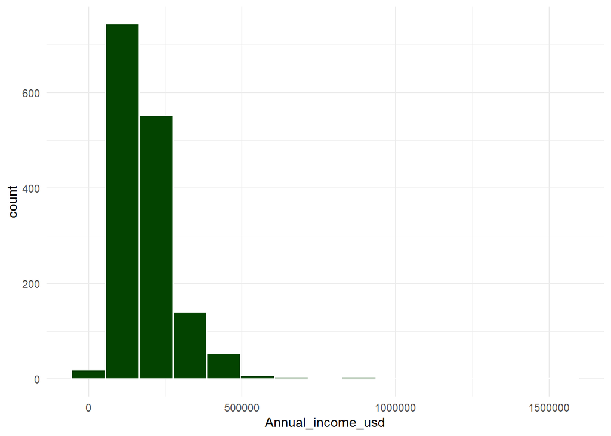

```r
CCC <- CCC %>%
  mutate(Annual_income_trimmed = (str_remove(Annual_income, "USD"))) %>%
  mutate(Annual_income_usd = as.numeric(Annual_income_trimmed)) %>%
  select(Annual_income_usd, Type_Income, EDUCATION, Marital_status)

CCC %>%
  ggplot(aes(x = Annual_income_usd)) +
  geom_histogram(color = "white", fill = "#034400", bins = 15) +
  theme_minimal()
```

**What can you say about the skewness in this graph? Explain**

The majority of the data is concentrated on the left side of the histogram. This indicates that most of the people have lower annual incomes, while a few individuals have **much higher** incomes.

## Part III. Detecting and dealing with outliers

3.1 Build a boxplot for the Annual_income_usd variable to identify potential outliers.

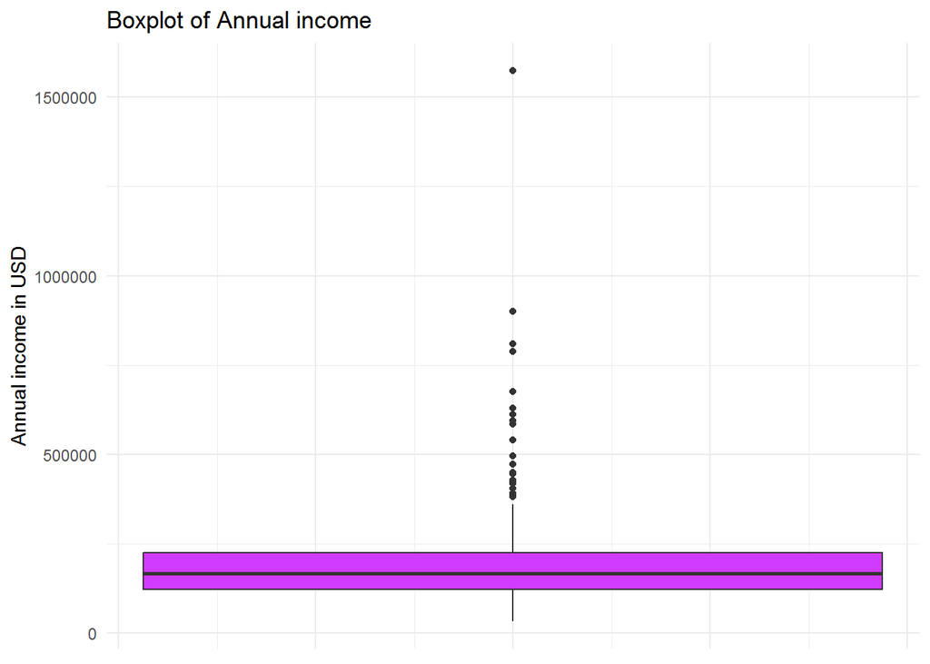

```r
CCC %>%
  ggplot(aes(y = Annual_income_usd)) +
  geom_boxplot(fill = "#d13bff") +
  theme_minimal() +
  theme(axis.text.x = element_blank()) +
  labs(y = "Annual income in USD", title = "Boxplot of Annual income")
```

**Do you notice any outliers in the dataset? Answer here**

The boxplot clearly shows the presence of several outliers in the data, with a significant number of individuals earning much higher incomes than the majority, contributing to the last right-skewed distribution.

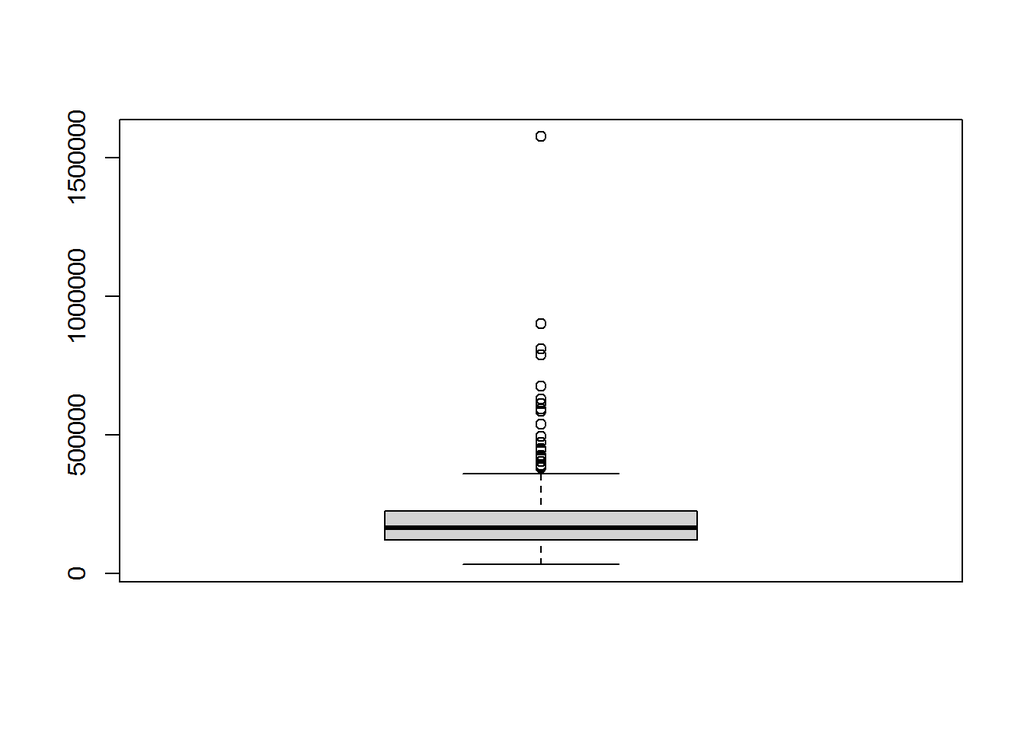

```
##  [1]  450000  450000  450000  472500  540000  540000  450000  391500  391500
## [10]  391500  675000  585000  585000  450000  450000  450000  450000  450000
## [19]  450000  445500 1575000 1575000  900000  450000  450000  423000  450000
## [28]  540000  450000  495000  612000  427500  612000  450000  787500  450000
## [37]  594000  585000  495000  387000  450000  900000  382500  450000  900000
## [46]  405000  405000  445500  450000  450000  450000  450000  405000  900000
## [55]  630000  450000  418500  450000  405000  405000  405000  495000  450000
## [64]  387000  810000  391500  405000  450000  405000  450000  450000  405000
## [73]  450000
```

```r
# Identify the outliers (there are 73 in total):
boxplot(CCC$Annual_income_usd)$out
```

```r
# Create an object ("out") that will keep the observations considered outliers. After that, create "out_index", this object will extract the outliers to properly identify them in the dataset.
out <- boxplot.stats(CCC$Annual_income_usd)$out
out_index <- which(CCC$Annual_income_usd %in% c(out))
CCC[out_index, ]
```

| Annual_income_usd | Type_Income | EDUCATION | Marital_status |
| --- | --- | --- | --- |
| 450000 | Commercial associate | Secondary / secondary special | Married |
| 450000 | Pensioner | Secondary / secondary special | Married |
| 450000 | Commercial associate | Secondary / secondary special | Single / not married |
| 472500 | Pensioner | Higher education | Married |
| 540000 | Commercial associate | Higher education | Married |
| 540000 | Commercial associate | Higher education | Married |
| 450000 | Commercial associate | Higher education | Separated |
| 391500 | Working | Secondary / secondary special | Single / not married |
| 391500 | Working | Secondary / secondary special | Single / not married |
| 391500 | Working | Secondary / secondary special | Single / not married |

[output cut: 63 more lines]

3.2 Find and show any observation with NA’s in Annual_income_usd.

```r
CCC[is.na(CCC$Annual_income_usd), ]
```

| Annual_income_usd | Type_Income | EDUCATION | Marital_status |
| --- | --- | --- | --- |
| NA | Commercial associate | Higher education | Married |
| NA | Working | Secondary / secondary special | Married |
| NA | Pensioner | Secondary / secondary special | Married |
| NA | Pensioner | Higher education | Separated |
| NA | Working | Secondary / secondary special | Single / not married |
| NA | Commercial associate | Higher education | Single / not married |
| NA | Pensioner | Secondary / secondary special | Married |
| NA | Commercial associate | Higher education | Married |
| NA | Working | Secondary / secondary special | Married |
| NA | Commercial associate | Secondary / secondary special | Married |

[output cut: 13 more lines]

3.3 Calculate the Interquartile Range for Annual_income_usd using the function IQR, remove any NA. Create an object to save the result IQR_AI, print the result.

```r
IQR_AI <- IQR(CCC$Annual_income_usd, na.rm = TRUE)
IQR_AI
```

```
## [1] 103500
```

**What is the IQR? Explain in your own words**

The Interquartile Range (IQR) measures the spread of the middle 50% of data and is calculated as the difference between the third and first quartiles, giving a good measure of variability by showing the range within which the central half of the data lies.

3.4 One popular technique to deal with outliers is to replace them with the mean or median of the variable. For the variable Annual_income_usd, replace any observation above Quartile3 + 1.5*IQR with the mean, create a new variable to do that: Annual_income_usd_mean. You can use the function quantile to get the quartiles, save Quartile 3 into an object Q3_AI.

```r
quantile(CCC$Annual_income_usd, na.rm = TRUE)
```

```
##      0%     25%     50%     75%    100%
##   33750  121500  166500  225000 1575000
```

```r
Q3_AI <- 225000
CCC %>%
  mutate(Annual_income_usd_mean = replace(Annual_income_usd, Annual_income_usd > Q3_AI + 1.5 * IQR_AI, mean(CCC$Annual_income_usd, na.rm = TRUE))) %>%
  drop_na() %>%
  select(Annual_income_usd, Annual_income_usd_mean)
```

| Annual_income_usd | Annual_income_usd_mean |
| --- | --- |
| 180000.0 | 180000.0 |
| 315000.0 | 315000.0 |
| 315000.0 | 315000.0 |
| 315000.0 | 315000.0 |
| 315000.0 | 315000.0 |
| 315000.0 | 315000.0 |
| 180000.0 | 180000.0 |
| 450000.0 | 191399.3 |
| 450000.0 | 191399.3 |
| 450000.0 | 191399.3 |

[output cut: 1515 more lines]

3.5 Another popular technique is to remove the outliers. It is better to create a safety copy of the dataset instead of changing the original one. Create a safety copy for CCC: CCC_deleted, for this, remove the outliers.Show the header of the new object.

```r
CCC_deleted <- CCC[-c(out_index), ]
head(CCC_deleted)
```

| Annual_income_usd | Type_Income | EDUCATION | Marital_status |
| --- | --- | --- | --- |
| 180000 | Pensioner | Higher education | Married |
| 315000 | Commercial associate | Higher education | Married |
| 315000 | Commercial associate | Higher education | Married |
| NA | Commercial associate | Higher education | Married |
| 315000 | Commercial associate | Higher education | Married |
| 315000 | Pensioner | Higher education | Married |

3.6 Now, determine how many NA’s you have for Annual_income_usd, then, drop them and create a new dataset: CCC_deleted_complete.

```r
sum(is.na(CCC_deleted$Annual_income_usd))
```

```
## [1] 23
```

```r
CCC_deleted_complete <- CCC_deleted %>%
  drop_na(Annual_income_usd)

head(CCC_deleted_complete)
```

| Annual_income_usd | Type_Income | EDUCATION | Marital_status |
| --- | --- | --- | --- |
| 180000 | Pensioner | Higher education | Married |
| 315000 | Commercial associate | Higher education | Married |
| 315000 | Commercial associate | Higher education | Married |
| 315000 | Commercial associate | Higher education | Married |
| 315000 | Pensioner | Higher education | Married |
| 315000 | Commercial associate | Higher education | Married |

3.7 Now, create a new boxplot, histogram (with 15 bins) and density plot that shows a line for the mean value, all for annual_income_usd variable.

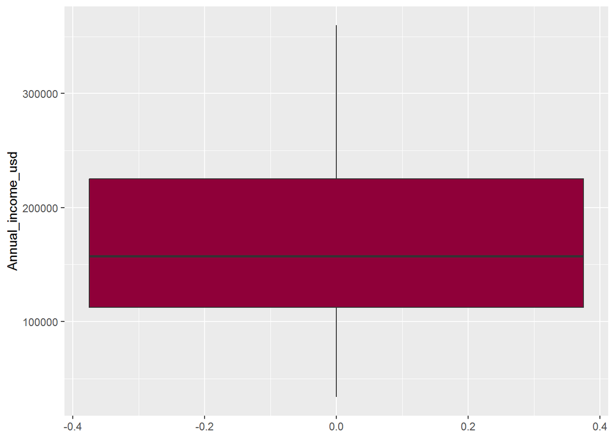

```r
options(scipen = 999) # This will avoid scientific notation in the numbers of the graph
CCC_deleted_complete %>%
  ggplot(aes(y = Annual_income_usd)) +
  geom_boxplot(fill = "#8f0039")
```

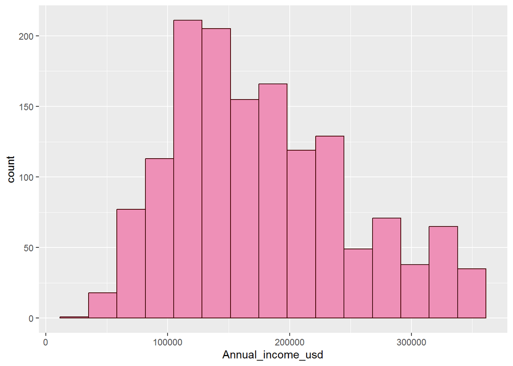

```r
CCC_deleted_complete %>%
  ggplot(aes(x = Annual_income_usd)) +
  geom_histogram(color = "#440000", fill = "#ee90b7", bins = 15)
```

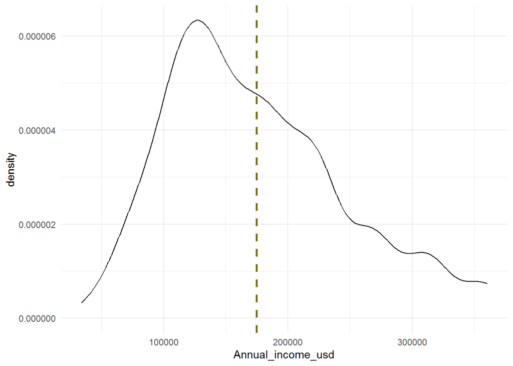

```r
CCC_deleted_complete %>%
  ggplot(aes(x = Annual_income_usd)) +
  geom_density() +
  geom_vline(aes(xintercept = mean(Annual_income_usd)), color = "#767000", linetype = "dashed", size = 1) +
  theme_minimal()
```

## Part IV. Modeling the relationship between three variables

```r
Ed_Vs_Marital <- table(CCC$EDUCATION, CCC$Marital_status) %>%
  addmargins()
Ed_Vs_Marital
```

```
##
##                                 Civil marriage Married Separated
##   Academic degree                            1       0         0
##   Higher education                          18     309        34
##   Incomplete higher                         10      39         5
##   Lower secondary                            2      14         0
##   Secondary / secondary special             70     687        57
##   Sum                                      101    1049        96
##
##                                 Single / not married Widow  Sum
##   Academic degree                                  1     0    2
##   Higher education                                59     6  426
##   Incomplete higher                               11     3   68
##   Lower secondary                                  3     2   21
##   Secondary / secondary special                  153    64 1031
##   Sum                                            227    75 1548
```

4.2 Finally, create a graph that shows in the x axis, the education level, in the y axis, the annual income in usd, and it is filled with the marital status variable.

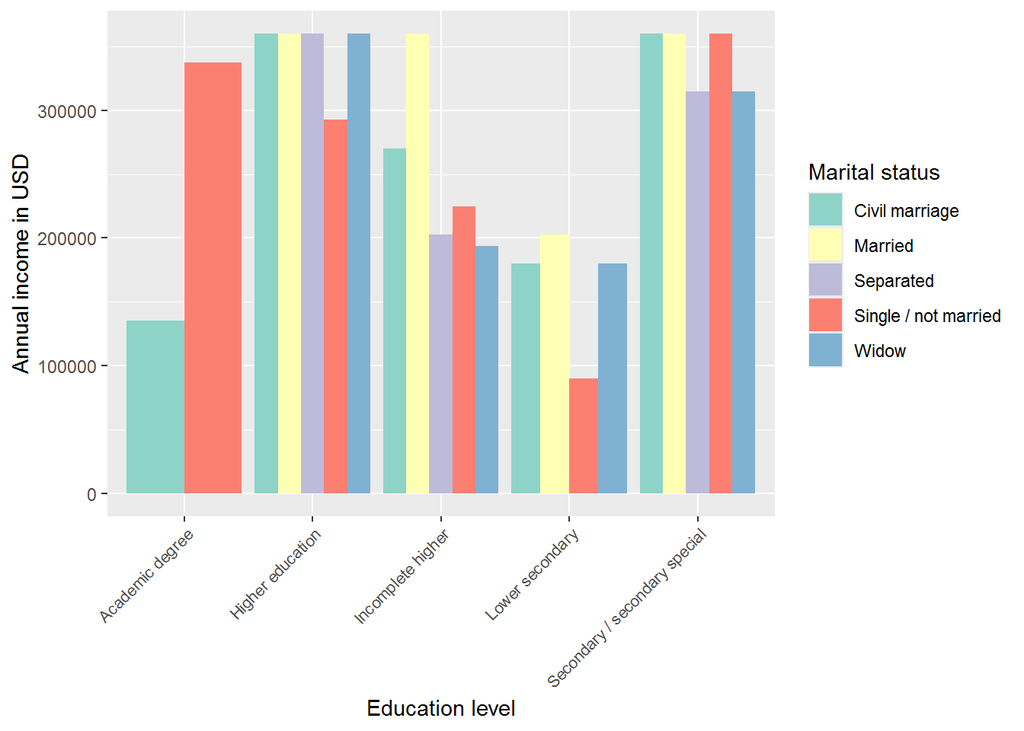

```r
Ed_Vs_Marital_df <- data.frame(Ed_Vs_Marital)

ggplot(CCC_deleted_complete, aes(
  fill = Marital_status, x = EDUCATION, y = Annual_income_usd
)) +
  geom_bar(position = "dodge", stat = "identity") +
  theme(axis.text.x = element_text(size = rel(0.9), angle = 45, hjust = 1)) +
  labs(
    x = "Education level", y = "Annual income in USD", fill = "Marital status"
  ) +
  scale_fill_brewer(palette = "Set3")
```

**Describe what you see in this graph**

- Academic degree: The lowest income for civil marriages and the highest for those who are single or not married. The plot doesn’t show anything about the others.
- Higher education: Generally high incomes across all marital statuses, with single/not married having the lowest incomes.
- Incomplete higher: Moderate to high incomes, with civil marriage and married individuals showing the highest ones.
- Lower secondary: Lower incomes compared to the others levels, with single/not married showing the lowest.
- Secondary: The highest incomes in the plot.